# AirPassenger_Demo_webinar

```python
from verticapy import *
import verticapy.stats as st
from verticapy.stats import seasonal_decompose
```

```python
from verticapy.connect import *
# Save a new connection
new_auto_connection({"host": "localhost",
                     "port": "5433",
                     "database": "testdb",
                     "password": "dbadmin",
                     "user": "dbadmin"},
                    name = "VerticaDSN")
# Set the main auto connection
change_auto_connection("VerticaDSN")
```

```python
data = vDataFrame("air_traffic")
```

```python
data
```

123

**ActivityPeriod**

Int

Abc

**OperatingAirline**

Varchar(66)

Abc

**OperatingAirlineIATACode**

Varchar(20)

Abc

**PublishedAirline**

Varchar(66)

Abc

**PublishedAirlineIATACode**

Varchar(20)

Abc

**GEOSummary**

Varchar(26)

Abc

**GEORegion**

Varchar(38)

Abc

**ActivityTypeCode**

Varchar(28)

Abc

**PriceCategoryCode**

Varchar(20)

Abc

**Terminal**

Varchar(26)

Abc

**BoardingArea**

Varchar(20)

123

**PassengerCount**

Int

**1**

200507

ATA Airlines

TZ

ATA Airlines

TZ

Domestic

US

Deplaned

Low Fare

Terminal 1

B

27271

**2**

200507

ATA Airlines

TZ

ATA Airlines

TZ

Domestic

US

Deplaned

Low Fare

Terminal 1

B

27271

**3**

200507

ATA Airlines

TZ

ATA Airlines

TZ

Domestic

US

Enplaned

Low Fare

Terminal 1

B

29131

**4**

200507

ATA Airlines

TZ

ATA Airlines

TZ

Domestic

US

Enplaned

Low Fare

Terminal 1

B

29131

**5**

200507

ATA Airlines

TZ

ATA Airlines

TZ

Domestic

US

Thru / Transit

Low Fare

Terminal 1

B

5415

**6**

200507

ATA Airlines

TZ

ATA Airlines

TZ

Domestic

US

Thru / Transit

Low Fare

Terminal 1

B

5415

**7**

200507

Air Canada

AC

Air Canada

AC

International

Canada

Deplaned

Other

Terminal 1

B

35156

**8**

200507

Air Canada

AC

Air Canada

AC

International

Canada

Deplaned

Other

Terminal 1

B

35156

**9**

200507

Air Canada

AC

Air Canada

AC

International

Canada

Enplaned

Other

Terminal 1

B

34090

**10**

200507

Air Canada

AC

Air Canada

AC

International

Canada

Enplaned

Other

Terminal 1

B

34090

**11**

200507

Air China

CA

Air China

CA

International

Asia

Deplaned

Other

International

G

6263

**12**

200507

Air China

CA

Air China

CA

International

Asia

Deplaned

Other

International

G

6263

**13**

200507

Air China

CA

Air China

CA

International

Asia

Enplaned

Other

International

G

5500

**14**

200507

Air China

CA

Air China

CA

International

Asia

Enplaned

Other

International

G

5500

**15**

200507

Air France

AF

Air France

AF

International

Europe

Deplaned

Other

International

A

12050

**16**

200507

Air France

AF

Air France

AF

International

Europe

Deplaned

Other

International

A

12050

**17**

200507

Air France

AF

Air France

AF

International

Europe

Enplaned

Other

International

A

11638

**18**

200507

Air France

AF

Air France

AF

International

Europe

Enplaned

Other

International

A

11638

**19**

200507

Air New Zealand

NZ

Air New Zealand

NZ

International

Australia / Oceania

Deplaned

Other

International

G

4998

**20**

200507

Air New Zealand

NZ

Air New Zealand

NZ

International

Australia / Oceania

Deplaned

Other

International

G

4998

**21**

200507

Air New Zealand

NZ

Air New Zealand

NZ

International

Australia / Oceania

Enplaned

Other

International

G

4962

**22**

200507

Air New Zealand

NZ

Air New Zealand

NZ

International

Australia / Oceania

Enplaned

Other

International

G

4962

**23**

200507

AirTran Airways

FL

AirTran Airways

FL

Domestic

US

Deplaned

Low Fare

International

A

8055

**24**

200507

AirTran Airways

FL

AirTran Airways

FL

Domestic

US

Deplaned

Low Fare

International

A

8055

**25**

200507

AirTran Airways

FL

AirTran Airways

FL

Domestic

US

Enplaned

Low Fare

International

A

7984

**26**

200507

AirTran Airways

FL

AirTran Airways

FL

Domestic

US

Enplaned

Low Fare

International

A

7984

**27**

200507

Alaska Airlines

AS

Alaska Airlines

AS

Domestic

US

Deplaned

Other

International

A

36641

**28**

200507

Alaska Airlines

AS

Alaska Airlines

AS

Domestic

US

Deplaned

Other

International

A

36641

**29**

200507

Alaska Airlines

AS

Alaska Airlines

AS

Domestic

US

Enplaned

Other

International

A

39379

**30**

200507

Alaska Airlines

AS

Alaska Airlines

AS

Domestic

US

Enplaned

Other

International

A

39379

**31**

200507

Alaska Airlines

AS

Alaska Airlines

AS

Domestic

US

Thru / Transit

Other

International

A

3678

**32**

200507

Alaska Airlines

AS

Alaska Airlines

AS

Domestic

US

Thru / Transit

Other

International

A

3678

**33**

200507

Alaska Airlines

AS

Alaska Airlines

AS

International

Canada

Deplaned

Other

International

A

7977

**34**

200507

Alaska Airlines

AS

Alaska Airlines

AS

International

Canada

Deplaned

Other

International

A

7977

**35**

200507

Alaska Airlines

AS

Alaska Airlines

AS

International

Canada

Enplaned

Other

International

A

8837

**36**

200507

Alaska Airlines

AS

Alaska Airlines

AS

International

Canada

Enplaned

Other

International

A

8837

**37**

200507

Alaska Airlines

AS

Alaska Airlines

AS

International

Mexico

Deplaned

Other

International

A

6969

**38**

200507

Alaska Airlines

AS

Alaska Airlines

AS

International

Mexico

Deplaned

Other

International

A

6969

**39**

200507

Alaska Airlines

AS

Alaska Airlines

AS

International

Mexico

Enplaned

Other

International

A

10046

**40**

200507

Alaska Airlines

AS

Alaska Airlines

AS

International

Mexico

Enplaned

Other

International

A

10046

**41**

200507

Alaska Airlines

AS

Alaska Airlines

AS

International

Mexico

Thru / Transit

Other

International

A

2266

**42**

200507

Alaska Airlines

AS

Alaska Airlines

AS

International

Mexico

Thru / Transit

Other

International

A

2266

**43**

200507

All Nippon Airways

NH

All Nippon Airways

NH

International

Asia

Deplaned

Other

International

G

6545

**44**

200507

All Nippon Airways

NH

All Nippon Airways

NH

International

Asia

Deplaned

Other

International

G

6545

**45**

200507

All Nippon Airways

NH

All Nippon Airways

NH

International

Asia

Enplaned

Other

International

G

6094

**46**

200507

All Nippon Airways

NH

All Nippon Airways

NH

International

Asia

Enplaned

Other

International

G

6094

**47**

200507

American Airlines

AA

American Airlines

AA

Domestic

US

Deplaned

Other

Terminal 3

E

166577

**48**

200507

American Airlines

AA

American Airlines

AA

Domestic

US

Deplaned

Other

Terminal 3

E

166577

**49**

200507

American Airlines

AA

American Airlines

AA

Domestic

US

Enplaned

Other

Terminal 3

E

160890

**50**

200507

American Airlines

AA

American Airlines

AA

Domestic

US

Enplaned

Other

Terminal 3

E

160890

**51**

200507

American Eagle Airlines

MQ

American Airlines

AA

Domestic

US

Deplaned

Other

Terminal 3

E

5493

**52**

200507

American Eagle Airlines

MQ

American Airlines

AA

Domestic

US

Deplaned

Other

Terminal 3

E

5493

**53**

200507

American Eagle Airlines

MQ

American Airlines

AA

Domestic

US

Enplaned

Other

Terminal 3

E

5213

**54**

200507

American Eagle Airlines

MQ

American Airlines

AA

Domestic

US

Enplaned

Other

Terminal 3

E

5213

**55**

200507

Asiana Airlines

OZ

Asiana Airlines

OZ

International

Asia

Deplaned

Other

International

A

5041

**56**

200507

Asiana Airlines

OZ

Asiana Airlines

OZ

International

Asia

Deplaned

Other

International

A

5041

**57**

200507

Asiana Airlines

OZ

Asiana Airlines

OZ

International

Asia

Enplaned

Other

International

A

4744

**58**

200507

Asiana Airlines

OZ

Asiana Airlines

OZ

International

Asia

Enplaned

Other

International

A

4744

**59**

200507

Atlantic Southeast Airlines

EV

Delta Air Lines

DL

Domestic

US

Deplaned

Other

Terminal 1

C

1552

**60**

200507

Atlantic Southeast Airlines

EV

Delta Air Lines

DL

Domestic

US

Deplaned

Other

Terminal 1

C

1552

**61**

200507

Atlantic Southeast Airlines

EV

Delta Air Lines

DL

Domestic

US

Enplaned

Other

Terminal 1

C

1484

**62**

200507

Atlantic Southeast Airlines

EV

Delta Air Lines

DL

Domestic

US

Enplaned

Other

Terminal 1

C

1484

**63**

200507

BelAir Airlines

4T

BelAir Airlines

4T

International

Europe

Deplaned

Other

International

A

325

**64**

200507

BelAir Airlines

4T

BelAir Airlines

4T

International

Europe

Deplaned

Other

International

A

325

**65**

200507

BelAir Airlines

4T

BelAir Airlines

4T

International

Europe

Enplaned

Other

International

A

545

**66**

200507

BelAir Airlines

4T

BelAir Airlines

4T

International

Europe

Enplaned

Other

International

A

545

**67**

200507

British Airways

BA

British Airways

BA

International

Europe

Deplaned

Other

International

A

20632

**68**

200507

British Airways

BA

British Airways

BA

International

Europe

Deplaned

Other

International

A

20632

**69**

200507

British Airways

BA

British Airways

BA

International

Europe

Enplaned

Other

International

A

21686

**70**

200507

British Airways

BA

British Airways

BA

International

Europe

Enplaned

Other

International

A

21686

**71**

200507

Cathay Pacific

CX

Cathay Pacific

CX

International

Asia

Deplaned

Other

International

A

11010

**72**

200507

Cathay Pacific

CX

Cathay Pacific

CX

International

Asia

Deplaned

Other

International

A

11010

**73**

200507

Cathay Pacific

CX

Cathay Pacific

CX

International

Asia

Enplaned

Other

International

A

9628

**74**

200507

Cathay Pacific

CX

Cathay Pacific

CX

International

Asia

Enplaned

Other

International

A

9628

**75**

200507

China Airlines

CI

China Airlines

CI

International

Asia

Deplaned

Other

International

A

13638

**76**

200507

China Airlines

CI

China Airlines

CI

International

Asia

Deplaned

Other

International

A

13638

**77**

200507

China Airlines

CI

China Airlines

CI

International

Asia

Enplaned

Other

International

A

11255

**78**

200507

China Airlines

CI

China Airlines

CI

International

Asia

Enplaned

Other

International

A

11255

**79**

200507

Delta Air Lines

DL

Delta Air Lines

DL

Domestic

US

Deplaned

Other

Terminal 1

C

97510

**80**

200507

Delta Air Lines

DL

Delta Air Lines

DL

Domestic

US

Deplaned

Other

Terminal 1

C

97510

**81**

200507

Delta Air Lines

DL

Delta Air Lines

DL

Domestic

US

Enplaned

Other

Terminal 1

C

93791

**82**

200507

Delta Air Lines

DL

Delta Air Lines

DL

Domestic

US

Enplaned

Other

Terminal 1

C

93791

**83**

200507

EVA Airways

BR

EVA Airways

BR

International

Asia

Deplaned

Other

International

G

14142

**84**

200507

EVA Airways

BR

EVA Airways

BR

International

Asia

Deplaned

Other

International

G

14142

**85**

200507

EVA Airways

BR

EVA Airways

BR

International

Asia

Enplaned

Other

International

G

12132

**86**

200507

EVA Airways

BR

EVA Airways

BR

International

Asia

Enplaned

Other

International

G

12132

**87**

200507

Frontier Airlines

F9

Frontier Airlines

F9

Domestic

US

Deplaned

Low Fare

Terminal 1

B

19234

**88**

200507

Frontier Airlines

F9

Frontier Airlines

F9

Domestic

US

Deplaned

Low Fare

Terminal 1

B

19234

**89**

200507

Frontier Airlines

F9

Frontier Airlines

F9

Domestic

US

Enplaned

Low Fare

Terminal 1

B

18368

**90**

200507

Frontier Airlines

F9

Frontier Airlines

F9

Domestic

US

Enplaned

Low Fare

Terminal 1

B

18368

**91**

200507

Hawaiian Airlines

HA

Hawaiian Airlines

HA

Domestic

US

Deplaned

Other

Terminal 1

C

7579

**92**

200507

Hawaiian Airlines

HA

Hawaiian Airlines

HA

Domestic

US

Deplaned

Other

Terminal 1

C

7579

**93**

200507

Hawaiian Airlines

HA

Hawaiian Airlines

HA

Domestic

US

Enplaned

Other

Terminal 1

C

7658

**94**

200507

Hawaiian Airlines

HA

Hawaiian Airlines

HA

Domestic

US

Enplaned

Other

Terminal 1

C

7658

**95**

200507

Horizon Air

QX

Alaska Airlines

AS

Domestic

US

Deplaned

Other

Terminal 1

B

5284

**96**

200507

Horizon Air

QX

Alaska Airlines

AS

Domestic

US

Deplaned

Other

Terminal 1

B

5284

**97**

200507

Horizon Air

QX

Alaska Airlines

AS

Domestic

US

Enplaned

Other

Terminal 1

B

5257

**98**

200507

Horizon Air

QX

Alaska Airlines

AS

Domestic

US

Enplaned

Other

Terminal 1

B

5257

**99**

200507

Icelandair (Inactive)

FI

Icelandair (Inactive)

FI

International

Europe

Deplaned

Other

International

A

4540

**100**

200507

Icelandair (Inactive)

FI

Icelandair (Inactive)

FI

International

Europe

Deplaned

Other

International

A

4540

**Rows:** 1-100 | **Columns:** 12

```python
data.count()
```

**count**

**percent**

**"ActivityPeriod"**

46670.0

100.0

**"OperatingAirline"**

46670.0

100.0

**"PublishedAirline"**

46670.0

100.0

**"GEOSummary"**

46670.0

100.0

**"GEORegion"**

46670.0

100.0

**"ActivityTypeCode"**

46670.0

100.0

**"PriceCategoryCode"**

46670.0

100.0

**"Terminal"**

46670.0

100.0

**"BoardingArea"**

46670.0

100.0

**"PassengerCount"**

46670.0

100.0

**"OperatingAirlineIATACode"**

46519.0

99.676

**"PublishedAirlineIATACode"**

46519.0

99.676

**Rows:** 1-12 | **Columns:** 3

```python
mindt= data["ActivityPeriod"].min()
print("First Date: " , mindt)
maxdt = data["ActivityPeriod"].max()
print("Last Date: " , maxdt)
```

```
First Date:  200507.0
Last Date:  202106.0
```

```python
data_agg = data.groupby(
                    columns = ["ActivityPeriod"],
                    expr = [(st.sum(data["PassengerCount"])/1000)._as("TotPassengerCount")])
```

```python
data_agg.count()
```

**count**

**percent**

**"ActivityPeriod"**

192.0

100.0

**"TotPassengerCount"**

192.0

100.0

**Rows:** 1-2 | **Columns:** 3

```python
data_agg.eval(name = "DtActivityPeriod",
             expr = "(ActivityPeriod::varchar(8)||'01')::date")
```

123

**ActivityPeriod**

Int

123

**TotPassengerCount**

Numeric(36,18)

📅

**DtActivityPeriod**

Date

**1**

200507

6451.538

2005-07-01

**2**

200508

6391.732

2005-08-01

**3**

200509

5481.106

2005-09-01

**4**

200510

5541.43

2005-10-01

**5**

200511

5234.666

2005-11-01

**6**

200512

5343.594

2005-12-01

**7**

200601

4897.778

2006-01-01

**8**

200602

4446.048

2006-02-01

**9**

200603

5417.556

2006-03-01

**10**

200604

5546.586

2006-04-01

**11**

200605

5658.0

2006-05-01

**12**

200606

6142.792

2006-06-01

**13**

200607

6455.21

2006-07-01

**14**

200608

6287.678

2006-08-01

**15**

200609

5440.2

2006-09-01

**16**

200610

5669.918

2006-10-01

**17**

200611

5307.774

2006-11-01

**18**

200612

5396.4

2006-12-01

**19**

200701

5014.86

2007-01-01

**20**

200702

4609.98

2007-02-01

**21**

200703

5640.17

2007-03-01

**22**

200704

5738.494

2007-04-01

**23**

200705

6113.868

2007-05-01

**24**

200706

6527.242

2007-06-01

**25**

200707

6764.764

2007-07-01

**26**

200708

6872.834

2007-08-01

**27**

200709

5915.06

2007-09-01

**28**

200710

6258.618

2007-10-01

**29**

200711

5845.0

2007-11-01

**30**

200712

5807.274

2007-12-01

**31**

200801

5340.106

2008-01-01

**32**

200802

5191.352

2008-02-01

**33**

200803

6254.774

2008-03-01

**34**

200804

6058.042

2008-04-01

**35**

200805

6611.908

2008-05-01

**36**

200806

6907.502

2008-06-01

**37**

200807

7207.892

2008-07-01

**38**

200808

7224.594

2008-08-01

**39**

200809

6009.44

2008-09-01

**40**

200810

6248.902

2008-10-01

**41**

200811

5488.97

2008-11-01

**42**

200812

5925.874

2008-12-01

**43**

200901

5289.078

2009-01-01

**44**

200902

4719.6

2009-02-01

**45**

200903

5851.836

2009-03-01

**46**

200904

6049.946

2009-04-01

**47**

200905

6354.2

2009-05-01

**48**

200906

6839.19

2009-06-01

**49**

200907

7299.404

2009-07-01

**50**

200908

7301.336

2009-08-01

**51**

200909

6383.052

2009-09-01

**52**

200910

6498.856

2009-10-01

**53**

200911

5942.968

2009-11-01

**54**

200912

6148.418

2009-12-01

**55**

201001

5570.932

2010-01-01

**56**

201002

5030.722

2010-02-01

**57**

201003

6211.916

2010-03-01

**58**

201004

6278.118

2010-04-01

**59**

201005

6760.71

2010-05-01

**60**

201006

7225.772

2010-06-01

**61**

201007

7531.648

2010-07-01

**62**

201008

7543.684

2010-08-01

**63**

201009

6712.73

2010-09-01

**64**

201010

6980.2

2010-10-01

**65**

201011

6327.318

2010-11-01

**66**

201012

6334.248

2010-12-01

**67**

201101

5767.62

2011-01-01

**68**

201102

5221.334

2011-02-01

**69**

201103

6258.41

2011-03-01

**70**

201104

6401.054

2011-04-01

**71**

201105

7095.608

2011-05-01

**72**

201106

7532.646

2011-06-01

**73**

201107

7871.178

2011-07-01

**74**

201108

7835.768

2011-08-01

**75**

201109

7129.94

2011-09-01

**76**

201110

7204.91

2011-10-01

**77**

201111

6653.718

2011-11-01

**78**

201112

6883.386

2011-12-01

**79**

201201

6423.2

2012-01-01

**80**

201202

5996.238

2012-02-01

**81**

201203

6944.88

2012-03-01

**82**

201204

7126.014

2012-04-01

**83**

201205

7641.14

2012-05-01

**84**

201206

8214.39

2012-06-01

**85**

201207

8568.886

2012-07-01

**86**

201208

8712.432

2012-08-01

**87**

201209

7638.758

2012-09-01

**88**

201210

7689.974

2012-10-01

**89**

201211

6957.78

2012-11-01

**90**

201212

6886.078

2012-12-01

**91**

201301

6409.274

2013-01-01

**92**

201302

5932.954

2013-02-01

**93**

201303

7186.728

2013-03-01

**94**

201304

7208.208

2013-04-01

**95**

201305

7866.032

2013-05-01

**96**

201306

8293.594

2013-06-01

**97**

201307

8352.972

2013-07-01

**98**

201308

8694.118

2013-08-01

**99**

201309

7562.336

2013-09-01

**100**

201310

7821.58

2013-10-01

**Rows:** 1-100 of 192 | **Columns:** 3

```python
%matplotlib inline
data_agg.hchart(x = "DtActivityPeriod",
                     y = ["TotPassengerCount"],
                     kind = "line")
```

[interactive chart not shown]

```python
train =data_agg[data_agg["ActivityPeriod"] < 201902]
```

```python
test =data_agg[data_agg["ActivityPeriod"] >= 201902]
```

## TRAIN data

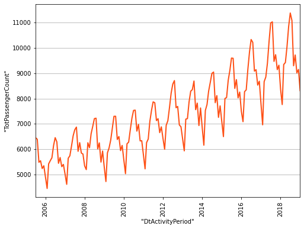

```python
%matplotlib inline
train["TotPassengerCount"].plot(ts = "DtActivityPeriod")
```

**value**

**confidence**

**0**

1.0

0.1535162272491033

**1**

0.911302689988447

0.2511935871740617

**2**

0.0354136219821969

0.25209121255003547

**3**

-0.191774920281698

0.25634578839576755

**4**

-0.0923575615825185

0.2579508117398035

**5**

0.14222457754155

0.26065945505537236

**6**

-0.0344140674093717

0.2615990591115187

**7**

0.748913873480836

0.31063708253344935

**8**

0.165113880100747

0.31379814961522895

**9**

0.382325026852177

0.3261918098616995

**10**

0.122159414595336

0.3283989731890482

**11**

0.479171659562128

0.34664235781507996

**12**

0.693492532169172

0.3813484318869317

**13**

-0.658441929244004

0.41061187739553745

**14**

-0.168081226920923

0.4137516153460474

**15**

-0.0863701646252875

0.41561321148529706

**16**

0.0178305565582563

0.4170443880144292

**17**

0.281729858601358

0.4234312829955335

**18**

0.0326093194095721

0.42495518038531777

**19**

-0.0424088223039028

0.4265406638832176

**20**

0.262462064782583

0.4323311918924803

**21**

-0.0149793291477631

0.4338648050077947

**22**

0.200549897503549

0.4379100911416213

**23**

0.0751128825340342

0.4398233944027214

**24**

0.146368426174094

0.44274197305495877

**25**

-0.210408422490783

0.4471080913758206

**26**

-0.103405145305588

0.4494045501778678

**27**

0.0920787364263256

0.4515843773393915

**28**

-0.0192247989477156

0.4532770286302539

**29**

0.182415193118917

0.45705710265990457

**30**

0.000766887820537529

0.45877218174447626

**31**

-0.149683203163898

0.4619204058876513

**32**

0.12266734481844

0.4646307562548943

**33**

-0.085755720278257

0.4668800571239108

**34**

0.00225108177675352

0.46868649823829867

**35**

0.309528961367006

0.476585623854991

**36**

0.122900295069391

0.4794122071479343

**37**

-0.139172720648557

0.4825362142883715

**38**

-0.0312225379622275

0.48452434926501964

**39**

0.0052005249684944

0.4864758756150867

**40**

-0.0844816696190622

0.48890555201863684

**41**

0.144978337223114

0.4922514988703371

**42**

0.110242278072663

0.4950614029540482

**43**

-0.0192094044489777

0.49714364056118815

**44**

0.197740054444702

0.5017501024930009

**45**

0.120908361537255

0.5048153040190512

**46**

0.276029349691738

0.5118787280450273

**47**

0.0199396091111351

0.5141059783260848

**48**

0.209795248461784

0.5191760302874876

**Rows:** 1-49 | **Columns:** 3

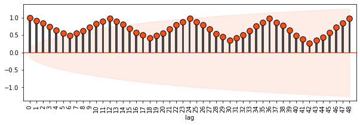

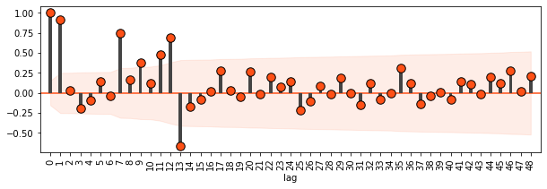

```python
train.acf(ts = "DtActivityPeriod",
           column = "TotPassengerCount",
           p = 48)
train.pacf(ts = "DtActivityPeriod",
            column = "TotPassengerCount",
            p = 48)
```

## TRAIN data (multiplicative decomposition)

```python
from verticapy.stats import adfuller
adfuller(train,
         column = "TotPassengerCount",
         ts = "DtActivityPeriod",
         p = 12,
         with_trend = False)
```

**value**

**ADF Test Statistic**

0.5386086163347139

**p_value**

0.59103743811115

**# Lags used**

12

**# Observations Used**

163

**Critical Value (1%)**

-3.46

**Critical Value (2.5%)**

-3.14

**Critical Value (5%)**

-2.88

**Critical Value (10%)**

-2.57

**Stationarity (alpha = 1%)**

❌

**Rows:** 1-9 | **Columns:** 2

```python
decomposition = seasonal_decompose(train,
                                   "TotPassengerCount",
                                   "DtActivityPeriod",
                                   polynomial_order = 2,
                                   mult = True,
                                  estimate_seasonality = False,
                                  period=12)
```

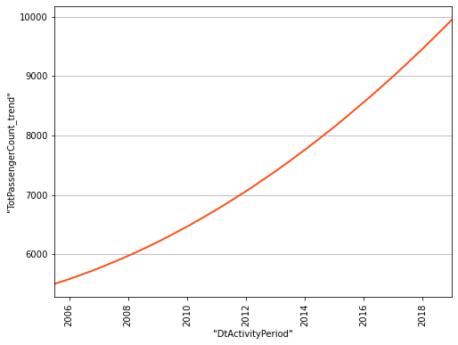

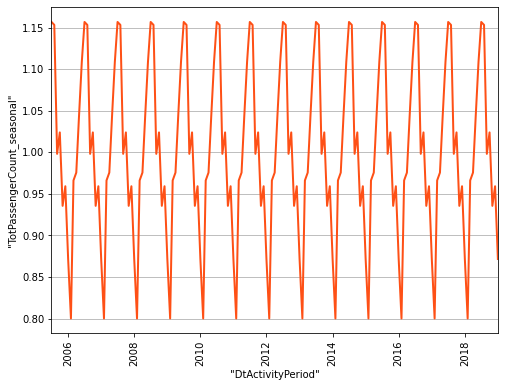

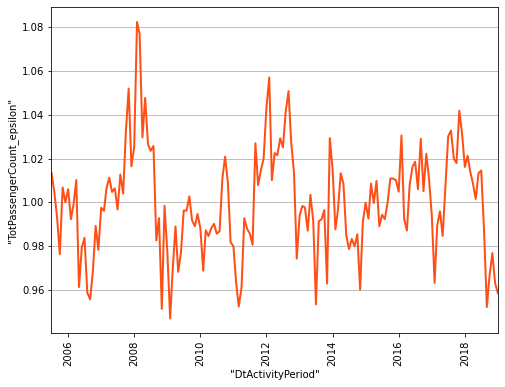

```python
decomposition["TotPassengerCount_trend"].plot(ts = "DtActivityPeriod",)
decomposition["TotPassengerCount_seasonal"].plot(ts = "DtActivityPeriod",)
decomposition["TotPassengerCount_epsilon"].plot(ts = "DtActivityPeriod",)
```

```python
from verticapy.stats import adfuller
adfuller(decomposition,
         column = "TotPassengerCount_epsilon",
         ts = "DtActivityPeriod",
         p = 12,
         with_trend = False)
```

**value**

**ADF Test Statistic**

-3.542214041816646

**p_value**

0.000544113444048906

**# Lags used**

12

**# Observations Used**

163

**Critical Value (1%)**

-3.46

**Critical Value (2.5%)**

-3.14

**Critical Value (5%)**

-2.88

**Critical Value (10%)**

-2.57

**Stationarity (alpha = 1%)**

✅

**Rows:** 1-9 | **Columns:** 2

The idea is to model each component with a different model. The trend and the seasonal component models are automatically created by the function seasonal_decompose, so we can focus on the noise part.

Using auto-correlation and partial auto-correlation plots we can try to understand which model to use.

**value**

**confidence**

**0**

1.0

0.1535162272491033

**1**

0.660497765672549

0.21071875403896348

**2**

0.117004675184453

0.21291189645562175

**3**

0.183271692097754

0.2173192547851013

**4**

0.0242417711294721

0.21806669584548638

**5**

-0.244136141140844

0.22528267877460553

**6**

-0.162398587576384

0.22883650586842486

**7**

0.128052071032653

0.23132096064156682

**8**

-0.122104938469774

0.2336528124347859

**9**

0.0408510578220702

0.23458771542453222

**10**

-0.154794277644491

0.23789555942582535

**11**

-0.0190958407402566

0.23871543639851178

**12**

-0.0344891965786723

0.23963089610920335

**13**

-0.013387964386947

0.24044743000679042

**14**

-0.0479674432442486

0.24149871020201027

**15**

-0.114815413503961

0.2437211950753036

**16**

0.0449571971441623

0.24476465752401022

**17**

-0.181993538405248

0.24912452622974934

**18**

-0.0345062730574835

0.25010825567327033

**19**

0.108741544792848

0.2522289333357468

**20**

-0.0529662118789695

0.25340688998621846

**21**

0.0229597823399544

0.2543536752904268

**22**

0.0230059959295341

0.255310530791349

**23**

-0.131347928864071

0.25806168559295234

**24**

-0.150568697411881

0.2613963005837035

**Rows:** 1-25 | **Columns:** 3

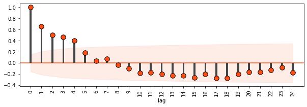

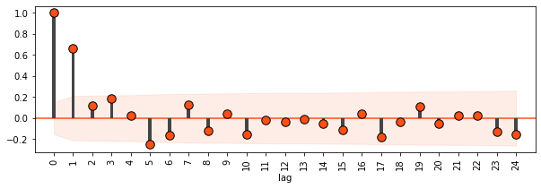

```python
decomposition.acf(ts = "DtActivityPeriod",
           column = "TotPassengerCount_epsilon",
           p = 24)
decomposition.pacf(ts = "DtActivityPeriod",
            column = "TotPassengerCount_epsilon",
            p = 24)
```

First we create a lagged version of the response variable.

```python
decomposition["lag_TotPassengerCount_epsilon"] = st.lag(decomposition["TotPassengerCount_epsilon"], 1)._over(
                                                                    order_by = [decomposition["DtActivityPeriod"]])
```

Then we can use a linear regression to implement an AR(1)

```python
from verticapy.learn.linear_model import LinearRegression
model = LinearRegression(name = "LR_airpassenger_noise")

model.drop()
model.fit(decomposition, ["lag_TotPassengerCount_epsilon"], "TotPassengerCount_epsilon")
```

```
=======
details
=======
          predictor          |coefficient|std_err |t_value |p_value
-----------------------------+-----------+--------+--------+--------
          Intercept          |  0.33369  | 0.05989| 5.57181| 0.00000
lag_totpassengercount_epsilon|  0.66605  | 0.05986|11.12732| 0.00000


==============
regularization
==============
type| lambda
----+--------
none| 1.00000


===========
call_string
===========
linear_reg('public.LR_airpassenger_noise', '"public"._VERTICAPY_TEMPORARY_VIEW_dbadmin_658', '"totpassengercount_epsilon"', '"lag_TotPassengerCount_epsilon"'
USING PARAMETERS optimizer='newton', epsilon=1e-06, max_iterations=100, regularization='none', lambda=1, alpha=0.5)

===============
Additional Info
===============
       Name       |Value
------------------+-----
 iteration_count  |  1
rejected_row_count|  1
accepted_row_count| 162
```

```python
model.regression_report()
```

**value**

**explained_variance**

0.433864893390152

**max_error**

0.0658789192504967

**median_absolute_error**

0.0104351769161943

**mean_absolute_error**

0.0136792677170731

**mean_squared_error**

0.000325015207547915

**root_mean_squared_error**

0.018028178153876643

**r2**

0.436257298457734

**r2_adj**

0.4327557909947385

**aic**

-1305.0820892366858

**bic**

-1298.9695888350723

**Rows:** 1-10 | **Columns:** 2

```python
model.predict(decomposition,
              X = ["lag_TotPassengerCount_epsilon"],
              name = "airpass_prediction_noise")
```

📅

**DtActivityPeriod**

Date

123

**TotPassengerCount**

Numeric(36,18)

123

**TotPassengerCount_trend**

Float

123

**TotPassengerCount_seasonal**

Float

123

**TotPassengerCount_epsilon**

Float

123

**lag_TotPassengerCount_epsilon**

Float

123

**airpass_prediction_noise**

Float

**1**

2005-07-01

6451.538

5503.35911280998

1.15670597390138

1.01347357189367

[null]

[null]

**2**

2005-08-01

6391.732

5516.48962789851

1.15316989586286

1.00476027185058

1.01347357189367

1.00871627560054

**3**

2005-09-01

5481.106

5529.79799258348

0.998150499729627

0.993031227919412

1.00476027185058

1.00291276093347

**4**

2005-10-01

5541.43

5543.28420686489

1.02393066824621

0.97630194593868

0.993031227919412

0.995100602721463

**5**

2005-11-01

5234.666

5556.94827074273

0.9356419009757

1.00679942753247

0.97630194593868

0.983958023805942

**6**

2005-12-01

5343.594

5570.79018421699

0.959201984125196

1.00001515897012

1.00679942753247

1.00427094553055

**7**

2006-01-01

4897.778

5584.8099472877

0.871758335415835

1.0059921433339

1.00001515897012

0.999752266968784

**8**

2006-02-01

4446.048

5599.00755995483

0.800234768512469

0.992306135303564

1.0059921433339

1.00373325192839

**9**

2006-03-01

5417.556

5613.3830222184

0.966178753875877

0.998898243048768

0.992306135303564

0.994617653022698

**10**

2006-04-01

5546.586

5627.9363340784

0.975624209710412

1.01016892996829

0.998898243048768

0.999008342405252

**11**

2006-05-01

5658.0

5642.66749553483

1.04314850021444

0.961241130870709

1.01016892996829

1.00651521081584

**12**

2006-06-01

6142.792

5657.5765065877

1.10867302802562

0.979336390270924

0.961241130870709

0.97392673133205

**13**

2006-07-01

6455.21

5672.663367237

1.15670597390138

0.983785426364905

0.979336390270924

0.985979122827151

**14**

2006-08-01

6287.678

5687.92807748273

1.15316989586286

0.9586120861387

0.983785426364905

0.988942414128731

**15**

2006-09-01

5440.2

5703.37063732489

0.998150499729627

0.955624426582136

0.9586120861387

0.9721756496997

**16**

2006-10-01

5669.918

5718.99104676349

1.02393066824621

0.968248450026462

0.955624426582136

0.97018571179202

**17**

2006-11-01

5307.774

5734.78930579852

0.9356419009757

0.989202700712813

0.968248450026462

0.978593973283566

**18**

2006-12-01

5396.4

5750.76541442998

0.959201984125196

0.978291799286111

0.989202700712813

0.992550602872164

**19**

2007-01-01

5014.86

5766.91937265788

0.871758335415835

0.997513599045216

0.978291799286111

0.985283370463353

**20**

2007-02-01

4609.98

5783.25118048221

0.800234768512469

0.996115205224174

0.997513599045216

0.998086096901993

**21**

2007-03-01

5640.17

5799.76083790297

0.966178753875877

1.00652513806644

0.996115205224174

0.997154693299383

**22**

2007-04-01

5738.494

5816.44834492016

0.975624209710412

1.01124756235823

1.00652513806644

1.00408825436517

**23**

2007-05-01

6113.868

5833.31370153379

1.04314850021444

1.00474207099061

1.01124756235823

1.00723363654024

**24**

2007-06-01

6527.242

5850.35690774385

1.10867302802562

1.00633799717713

1.00474207099061

1.00290063820645

**25**

2007-07-01

6764.764

5867.57796355034

1.15670597390138

0.996714560558799

1.00633799717713

1.00396360872109

**26**

2007-08-01

6872.834

5884.97686895326

1.15316989586286

1.0127396137963

0.996714560558799

0.997553895376447

**27**

2007-09-01

5915.06

5902.55362395262

0.998150499729627

1.00397566095287

1.0127396137963

1.00822742102626

**28**

2007-10-01

6258.618

5920.30822854841

1.02393066824621

1.03243703739071

1.00397566095287

1.00239016893844

**29**

2007-11-01

5845.0

5938.24068274063

0.9356419009757

1.05200319029733

1.03243703739071

1.02134693787617

**30**

2007-12-01

5807.274

5956.35098652929

0.959201984125196

1.01644051553053

1.05200319029733

1.03437902156549

**31**

2008-01-01

5340.106

5974.63913991438

0.871758335415835

1.02527906464974

1.01644051553053

1.01069241561956

**32**

2008-02-01

5191.352

5993.1051428959

0.800234768512469

1.08245827198863

1.02527906464974

1.01657935273813

**33**

2008-03-01

6254.774

6011.74899547385

0.966178753875877

1.07684525702264

1.08245827198863

1.05466370273202

**34**

2008-04-01

6058.042

6030.57069764824

0.975624209710412

1.02965396963767

1.07684525702264

1.05092514047426

**35**

2008-05-01

6611.908

6049.57024941906

1.04314850021444

1.0477463095497

1.02965396963767

1.01949326883639

**36**

2008-06-01

6907.502

6068.74765078631

1.10867302802562

1.02664065449538

1.0477463095497

1.03154371579929

**37**

2008-07-01

7207.892

6088.10290175

1.15670597390138

1.02353643725162

1.02664065449538

1.0174862429635

**38**

2008-08-01

7224.594

6107.63600231012

1.15316989586286

1.02576293761361

1.02353643725162

1.01541867152502

**39**

2008-09-01

6009.44

6127.34695246667

0.998150499729627

0.982574530526413

1.02576293761361

1.01690163750153

**40**

2008-10-01

6248.902

6147.23575221965

1.02393066824621

0.992780626967843

0.982574530526413

0.988135894013019

**41**

2008-11-01

5488.97

6167.30240156907

0.9356419009757

0.951230902677996

0.992780626967843

0.994933689348709

**42**

2008-12-01

5925.874

6187.54690051492

0.959201984125196

0.998444297056287

0.951230902677996

0.967259394519379

**43**

2009-01-01

5289.078

6207.9692490572

0.871758335415835

0.977314418739779

0.998444297056287

0.998705990573869

**44**

2009-02-01

4719.6

6228.56944719591

0.800234768512469

0.946889857592722

0.977314418739779

0.984632383775429

**45**

2009-03-01

5851.836

6249.34749493106

0.966178753875877

0.969170059140453

0.946889857592722

0.964368030891567

**46**

2009-04-01

6049.946

6270.30339226264

0.975624209710412

0.98896375390777

0.969170059140453

0.979207813273456

**47**

2009-05-01

6354.2

6291.43713919065

1.04314850021444

0.9681995590864

0.98896375390777

0.992391451772023

**48**

2009-06-01

6839.19

6312.7487357151

1.10867302802562

0.977198256415599

0.9681995590864

0.978561409354132

**49**

2009-07-01

7299.404

6334.23818183598

1.15670597390138

0.996253896182608

0.977198256415599

0.984555013577133

**50**

2009-08-01

7301.336

6355.90547755329

1.15316989586286

0.99616575590437

0.996253896182608

0.997247068749268

**51**

2009-09-01

6383.052

6377.75062286703

0.998150499729627

1.00268569738731

0.99616575590437

0.997188362702766

**52**

2009-10-01

6498.856

6399.77361777721

1.02393066824621

0.99174895464396

1.00268569738731

1.00153098557097

**53**

2009-11-01

5942.968

6421.97446228382

0.9356419009757

0.989065731439725

0.99174895464396

0.994246541490416

**54**

2009-12-01

6148.418

6444.35315638686

0.959201984125196

0.994658468966495

0.989065731439725

0.992459374154987

**55**

2010-01-01

5570.932

6466.90970008634

0.871758335415835

0.988177479230655

0.994658468966495

0.996184430575078

**56**

2010-02-01

5030.722

6489.64409338225

0.800234768512469

0.96870607267627

0.988177479230655

0.991867751612678

**57**

2010-03-01

6211.916

6512.55633627459

0.966178753875877

0.987226030589454

0.96870607267627

0.978898773961496

**58**

2010-04-01

6278.118

6535.64642876336

0.975624209710412

0.984596655629545

0.987226030589454

0.991234036933181

**59**

2010-05-01

6760.71

6558.91437084857

1.04314850021444

0.988130280836686

0.984596655629545

0.989482735351736

**60**

2010-06-01

7225.772

6582.36016253021

1.10867302802562

0.990145755641228

0.988130280836686

0.991836315007683

**61**

2010-07-01

7531.648

6605.98380380828

1.15670597390138

0.985665444860761

0.990145755641228

0.993178726898864

**62**

2010-08-01

7543.684

6629.78529468278

1.15316989586286

0.986712721255125

0.985665444860761

0.990194605016352

**63**

2010-09-01

6712.73

6653.76463515372

0.998150499729627

1.01073130312936

0.986712721255125

0.990892146003706

**64**

2010-10-01

6980.2

6677.92182522109

1.02393066824621

1.02083601790909

1.01073130312936

1.00688978082634

**65**

2010-11-01

6327.318

6702.25686488489

0.9356419009757

1.00899480696404

1.02083601790909

1.01362005065989

**66**

2010-12-01

6334.248

6726.76975414513

0.959201984125196

0.981699187959787

1.00899480696404

1.00573318333573

**67**

2011-01-01

5767.62

6751.4604930018

0.871758335415835

0.979947478662996

0.981699187959787

0.98755286996943

**68**

2011-02-01

5221.334

6776.3290814549

0.800234768512469

0.962874244070775

0.979947478662996

0.986386139735638

**69**

2011-03-01

6258.41

6801.37551950444

0.966178753875877

0.952378919880074

0.962874244070775

0.975014470347428

**70**

2011-04-01

6401.054

6826.5998071504

0.975624209710412

0.961090928820772

0.952378919880074

0.968024034166512

**71**

2011-05-01

7095.608

6852.0019443928

1.04314850021444

0.992718234478019

0.961090928820772

0.973826688891697

**72**

2011-06-01

7532.646

6877.58193123163

1.10867302802562

0.987889349334689

0.992718234478019

0.994892132679247

**73**

2011-07-01

7871.178

6903.3397676669

1.15670597390138

0.985728937780028

0.987889349334689

0.991675841995313

**74**

2011-08-01

7835.768

6929.2754536986

1.15316989586286

0.98061932320386

0.985728937780028

0.990236894629518

**75**

2011-09-01

7129.94

6955.38898932673

0.998150499729627

1.02699522214335

0.98061932320386

0.986833623424667

**76**

2011-10-01

7204.91

6981.68037455129

1.02393066824621

1.00785498113064

1.02699522214335

1.01772240360703

**77**

2011-11-01

6653.718

7008.14960937229

0.9356419009757

1.01473201655599

1.00785498113064

1.00497399956961

**78**

2011-12-01

6883.386

7034.79669378972

0.959201984125196

1.0200947324054

1.01473201655599

1.0095544657259

**79**

2012-01-01

6423.2

7061.62162780358

0.871758335415835

1.04340014461158

1.0200947324054

1.01312631564883

**80**

2012-02-01

5996.238

7088.62441141387

0.800234768512469

1.05705961207768

1.04340014461158

1.02864894208105

**81**

2012-03-01

6944.88

7115.8050446206

0.966178753875877

1.01014384473722

1.05705961207768

1.03774686357943

**82**

2012-04-01

7126.014

7143.16352742376

0.975624209710412

1.02252399972489

1.01014384473722

1.00649850273673

**83**

2012-05-01

7641.14

7170.69985982335

1.04314850021444

1.02152846784253

1.02252399972489

1.01474433505011

**84**

2012-06-01

8214.39

7198.41404181938

1.10867302802562

1.02928350564872

1.02152846784253

1.01408125862072

**85**

2012-07-01

8568.886

7226.30607341184

1.15670597390138

1.02514437758135

1.02928350564872

1.01924652039632

**86**

2012-08-01

8712.432

7254.37595460073

1.15316989586286

1.04146827759958

1.02514437758135

1.01648964408894

**87**

2012-09-01

7638.758

7282.62368538605

0.998150499729627

1.0508454636049

1.04146827759958

1.02736221736326

**88**

2012-10-01

7689.974

7311.04926576781

1.02393066824621

1.02724635769855

1.0508454636049

1.03360791488872

**89**

2012-11-01

6957.78

7339.652695746

0.9356419009757

1.01317746069327

1.02724635769855

1.01788967305383

**90**

2012-12-01

6886.078

7368.43397532062

0.959201984125196

0.974286473155422

1.01317746069327

1.00851905001596

**91**

2013-01-01

6409.274

7397.39310449168

0.871758335415835

0.993880183617103

0.974286473155422

0.982615613261042

**92**

2013-02-01

5932.954

7426.53008325917

0.800234768512469

0.998315053567165

0.993880183617103

0.995666051726877

**93**

2013-03-01

7186.728

7455.84491162309

0.966178753875877

0.997646904320511

0.998315053567165

0.998619907633877

**94**

2013-04-01

7208.208

7485.33758958344

0.975624209710412

0.98703681085908

0.997646904320511

0.998174885204536

**95**

2013-05-01

7866.032

7515.00811714023

1.04314850021444

1.00341390912616

0.98703681085908

0.99110800667196

**96**

2013-06-01

8293.594

7544.85649429345

1.10867302802562

0.991489925025393

1.00341390912616

1.00201601276919

**97**

2013-07-01

8352.972

7574.8827210431

1.15670597390138

0.953327528215589

0.991489925025393

0.994074014183526

**98**

2013-08-01

8694.118

7605.08679738918

1.15316989586286

0.991352392163995

0.953327528215589

0.968655857053505

**99**

2013-09-01

7562.336

7635.4687233317

0.998150499729627

0.992257153168794

0.991352392163995

0.993982410086987

**100**

2013-10-01

7821.58

7666.02849887065

1.02393066824621

0.996445410694922

0.992257153168794

0.994585028352808

**Rows:** 1-100 | **Columns:** 7

```python
decomposition.hchart(x = "DtActivityPeriod",
                     y = ["airpass_prediction_noise", "TotPassengerCount_epsilon"],
                     kind = "line")
```

[interactive chart not shown]

```python
decomposition["res"] = decomposition["airpass_prediction_noise"] - decomposition["TotPassengerCount_epsilon"]
decomposition.hchart(x = "DtActivityPeriod",
                     y = ["res"],
                     kind = "line")
```

[interactive chart not shown]

Durbin watson test to check autocorrelation in the residuals

```python
from verticapy.stats import durbin_watson
durbin_watson(decomposition,
              eps = "res",
              ts = "DtActivityPeriod")
```

```
0.00587165878357497
```

The last step will be to combine the 3 components together.

```python
decomposition["final_pred"] = decomposition["airpass_prediction_noise"] * decomposition["TotPassengerCount_seasonal"] * decomposition["TotPassengerCount_trend"]
```

```python
decomposition.hchart(x = "DtActivityPeriod",
                     y = ["final_pred", "TotPassengerCount"],
                     kind = "line")
```

[interactive chart not shown]

```python
# Computing MSE
decomposition.score(y_true  = "TotPassengerCount",
                       y_score = "final_pred",
                       method  = "mse")
```

```
16362.1543335187
```

```python
# Computing Max error
decomposition.score(y_true  = "TotPassengerCount",
                       y_score = "final_pred",
                       method  = "max")
```

```
402.97102409654
```

To apply the model to Test Data, we must first get the model for the trend, and the seasonal components.

```python
print(decomposition.current_relation())
```

```
(
   SELECT
     "DtActivityPeriod",
     "TotPassengerCount",
     "TotPassengerCount_trend",
     "TotPassengerCount_seasonal",
     "TotPassengerCount_epsilon",
     "lag_TotPassengerCount_epsilon",
     "airpass_prediction_noise",
     "res",
     "final_pred"
   FROM
 (
   SELECT
     "DtActivityPeriod",
     "TotPassengerCount",
     "TotPassengerCount_trend",
     "TotPassengerCount_seasonal",
     "row_number_id",
     "TotPassengerCount_epsilon",
     "lag_TotPassengerCount_epsilon",
     "airpass_prediction_noise",
     ("airpass_prediction_noise") - ("TotPassengerCount_epsilon") AS "res",
     (("airpass_prediction_noise") * ("TotPassengerCount_seasonal")) * ("TotPassengerCount_trend") AS "final_pred"
   FROM
 (
   SELECT
     "DtActivityPeriod",
     "TotPassengerCount",
     "TotPassengerCount_trend",
     "TotPassengerCount_seasonal",
     "row_number_id",
     "TotPassengerCount_epsilon",
     "lag_TotPassengerCount_epsilon",
     PREDICT_LINEAR_REG("lag_TotPassengerCount_epsilon" USING PARAMETERS model_name = 'LR_airpassenger_noise', match_by_pos = 'true') AS "airpass_prediction_noise"
   FROM
 (
   SELECT
     "DtActivityPeriod",
     "TotPassengerCount",
```

[output cut: 75 more lines]

```
VERTICAPY_SUBTABLE)
VERTICAPY_SUBTABLE)
VERTICAPY_SUBTABLE WHERE ("ActivityPeriod") < (201902))
VERTICAPY_SUBTABLE)
VERTICAPY_SUBTABLE)
VERTICAPY_SUBTABLE)
VERTICAPY_SUBTABLE)
VERTICAPY_SUBTABLE)
VERTICAPY_SUBTABLE)
VERTICAPY_SUBTABLE)
VERTICAPY_SUBTABLE)
VERTICAPY_SUBTABLE)
VERTICAPY_SUBTABLE)
VERTICAPY_SUBTABLE)
VERTICAPY_SUBTABLE
```

trend: 5490.40644731787 + 12.863740693889 *t + 0.0889247982163881* t^2

For the seasonal part, we can extract the repeating values from the training data.

```python
decomposition.eval(name = "Month", expr = "MONTH(DtActivityPeriod)")
seasonal_comp = decomposition[["TotPassengerCount_seasonal","Month"]].drop_duplicates()
seasonal_comp.sort({"Month": "asc"})
```

```
151 elements were filtered.
```

123

**TotPassengerCount_seasonal**

Float

123

**Month**

Int

**1**

0.871758335415835

1

**2**

0.800234768512469

2

**3**

0.966178753875877

3

**4**

0.975624209710412

4

**5**

1.04314850021444

5

**6**

1.10867302802562

6

**7**

1.15670597390138

7

**8**

1.15316989586286

8

**9**

0.998150499729627

9

**10**

1.02393066824621

10

**11**

0.9356419009757

11

**12**

0.959201984125196

12

**Rows:** 12 | **Columns:** 2

```python
drop("air_traffic_seasonal_comp")
seasonal_comp.to_db(name = "air_traffic_seasonal_comp",
                            relation_type= "table")
```

123

**TotPassengerCount_seasonal**

Float

123

**Month**

Int

**1**

0.871758335415835

1

**2**

0.800234768512469

2

**3**

0.966178753875877

3

**4**

0.975624209710412

4

**5**

1.04314850021444

5

**6**

1.10867302802562

6

**7**

1.15670597390138

7

**8**

1.15316989586286

8

**9**

0.998150499729627

9

**10**

1.02393066824621

10

**11**

0.9356419009757

11

**12**

0.959201984125196

12

**Rows:** 12 | **Columns:** 2

To calculate the trend component in the test dataset, we need to create the variable "t" which is the number of the interval. To do so, we need the last value of the train time series.

The last value in the train dataset is t = 163

## Test Data

```python
test
```

123

**ActivityPeriod**

Int

123

**TotPassengerCount**

Numeric(36,18)

📅

**DtActivityPeriod**

Date

**1**

201902

7505.526

2019-02-01

**2**

201903

9198.378

2019-03-01

**3**

201904

9385.882

2019-04-01

**4**

201905

10016.002

2019-05-01

**5**

201906

10933.376

2019-06-01

**6**

201907

11224.624

2019-07-01

**7**

201908

11484.874

2019-08-01

**8**

201909

8942.816

2019-09-01

**9**

201910

9649.118

2019-10-01

**10**

201911

8740.926

2019-11-01

**11**

201912

9441.984

2019-12-01

**12**

202001

8483.502

2020-01-01

**13**

202002

7484.448

2020-02-01

**14**

202003

3770.932

2020-03-01

**15**

202004

277.634

2020-04-01

**16**

202005

573.14

2020-05-01

**17**

202006

1110.238

2020-06-01

**18**

202007

1530.548

2020-07-01

**19**

202008

1705.156

2020-08-01

**20**

202009

1811.984

2020-09-01

**21**

202010

2147.764

2020-10-01

**22**

202011

2104.634

2020-11-01

**23**

202012

1837.446

2020-12-01

**24**

202101

1539.816

2021-01-01

**25**

202102

1472.648

2021-02-01

**26**

202103

2320.04

2021-03-01

**27**

202104

1455.944

2021-04-01

**28**

202105

1739.021

2021-05-01

**29**

202106

2245.539

2021-06-01

**Rows:** 1-29 | **Columns:** 3

```python
test["t"] = "163 + ROW_NUMBER() OVER( ORDER BY DtActivityPeriod)"
```

Next we create the month variable to be able to join the seasonal component

```python
test.eval(name = "Month", expr = "MONTH(DtActivityPeriod)")
```

123

**ActivityPeriod**

Int

123

**TotPassengerCount**

Numeric(36,18)

📅

**DtActivityPeriod**

Date

123

**t**

Integer

123

**Month**

Integer

**1**

201902

7505.526

2019-02-01

164

2

**2**

201903

9198.378

2019-03-01

165

3

**3**

201904

9385.882

2019-04-01

166

4

**4**

201905

10016.002

2019-05-01

167

5

**5**

201906

10933.376

2019-06-01

168

6

**6**

201907

11224.624

2019-07-01

169

7

**7**

201908

11484.874

2019-08-01

170

8

**8**

201909

8942.816

2019-09-01

171

9

**9**

201910

9649.118

2019-10-01

172

10

**10**

201911

8740.926

2019-11-01

173

11

**11**

201912

9441.984

2019-12-01

174

12

**12**

202001

8483.502

2020-01-01

175

1

**13**

202002

7484.448

2020-02-01

176

2

**14**

202003

3770.932

2020-03-01

177

3

**15**

202004

277.634

2020-04-01

178

4

**16**

202005

573.14

2020-05-01

179

5

**17**

202006

1110.238

2020-06-01

180

6

**18**

202007

1530.548

2020-07-01

181

7

**19**

202008

1705.156

2020-08-01

182

8

**20**

202009

1811.984

2020-09-01

183

9

**21**

202010

2147.764

2020-10-01

184

10

**22**

202011

2104.634

2020-11-01

185

11

**23**

202012

1837.446

2020-12-01

186

12

**24**

202101

1539.816

2021-01-01

187

1

**25**

202102

1472.648

2021-02-01

188

2

**26**

202103

2320.04

2021-03-01

189

3

**27**

202104

1455.944

2021-04-01

190

4

**28**

202105

1739.021

2021-05-01

191

5

**29**

202106

2245.539

2021-06-01

192

6

**Rows:** 1-29 | **Columns:** 5

```python
test_j = test.join(seasonal_comp,
             how = "left",
             on = {"Month": "Month"},
             expr1 = ["*"],
             expr2 = ["TotPassengerCount_seasonal AS TotPassengerCount_seasonal"])
```

```python
test_j
```

123

**ActivityPeriod**

Int

123

**TotPassengerCount**

Numeric(36,18)

📅

**DtActivityPeriod**

Date

123

**t**

Int

123

**Month**

Int

123

**TotPassengerCount_seasonal**

Float

**1**

201902

7505.526

2019-02-01

164

2

0.800234768512469

**2**

201903

9198.378

2019-03-01

165

3

0.966178753875877

**3**

201904

9385.882

2019-04-01

166

4

0.975624209710412

**4**

201905

10016.002

2019-05-01

167

5

1.04314850021444

**5**

201906

10933.376

2019-06-01

168

6

1.10867302802562

**6**

201907

11224.624

2019-07-01

169

7

1.15670597390138

**7**

201908

11484.874

2019-08-01

170

8

1.15316989586286

**8**

201909

8942.816

2019-09-01

171

9

0.998150499729627

**9**

201910

9649.118

2019-10-01

172

10

1.02393066824621

**10**

201911

8740.926

2019-11-01

173

11

0.9356419009757

**11**

201912

9441.984

2019-12-01

174

12

0.959201984125196

**12**

202001

8483.502

2020-01-01

175

1

0.871758335415835

**13**

202002

7484.448

2020-02-01

176

2

0.800234768512469

**14**

202003

3770.932

2020-03-01

177

3

0.966178753875877

**15**

202004

277.634

2020-04-01

178

4

0.975624209710412

**16**

202005

573.14

2020-05-01

179

5

1.04314850021444

**17**

202006

1110.238

2020-06-01

180

6

1.10867302802562

**18**

202007

1530.548

2020-07-01

181

7

1.15670597390138

**19**

202008

1705.156

2020-08-01

182

8

1.15316989586286

**20**

202009

1811.984

2020-09-01

183

9

0.998150499729627

**21**

202010

2147.764

2020-10-01

184

10

1.02393066824621

**22**

202011

2104.634

2020-11-01

185

11

0.9356419009757

**23**

202012

1837.446

2020-12-01

186

12

0.959201984125196

**24**

202101

1539.816

2021-01-01

187

1

0.871758335415835

**25**

202102

1472.648

2021-02-01

188

2

0.800234768512469

**26**

202103

2320.04

2021-03-01

189

3

0.966178753875877

**27**

202104

1455.944

2021-04-01

190

4

0.975624209710412

**28**

202105

1739.021

2021-05-01

191

5

1.04314850021444

**29**

202106

2245.539

2021-06-01

192

6

1.10867302802562

**Rows:** 1-29 | **Columns:** 6

```python
test_j["TotPassengerCount_trend"] = "5490.40644731787 + 12.863740693889 * t + 0.0889247982163881 * POWER(t, 2)"
```

We remove the first two components from the series to get the noise component

```python
test_j["TotPassengerCount_epsilon"] = test_j["TotPassengerCount"] / test_j["TotPassengerCount_seasonal"]/test_j["TotPassengerCount_trend"]
```

```python
test_j
```

Int

123

**TotPassengerCount**

Numeric(36,18)

📅

**DtActivityPeriod**

Date

123

**t**

Int

123

**Month**

Int

123

**TotPassengerCount_seasonal**

Float

123

**TotPassengerCount_trend**

Float

123

**TotPassengerCount_epsilon**

Float

123

**lag_TotPassengerCount_epsilon**

Float

123

**airpass_epsilon_prediction**

Float

123

**final_pred**

Float

123

**res**

Float

123

**initial_shock**

Integer

123

**permanent_shock**

Integer

123

**final_pred2**

Float

**1**

201902

7505.526

2019-02-01

164

2

0.800234768512469

9991.78129394364

0.938686987957292

[null]

[null]

[null]

[null]

0

0

[null]

**2**

201903

9198.378

2019-03-01

165

3

0.966178753875877

10033.9012932507

0.948820250061055

0.938686987957292

0.958904489637866

9296.14008661662

97.7620866166199

0

0

9296.14008661662

**3**

201904

9385.882

2019-04-01

166

4

0.975624209710412

10076.1991421542

0.954763436956781

0.948820250061055

0.965653773485965

9492.94036613205

107.058366132052

0

0

9492.94036613205

**4**

201905

10016.002

2019-05-01

167

5

1.04314850021444

10118.6748406542

0.948909127995795

0.954763436956781

0.969612247559843

10234.5292338962

218.527233896166

0

0

10234.5292338962

**5**

201906

10933.376

2019-06-01

168

6

1.10867302802562

10161.3283887506

0.970510670770227

0.948909127995795

0.965712970850373

10879.3270763366

-54.0489236633621

0

0

10879.3270763366

**6**

201907

11224.624

2019-07-01

169

7

1.15670597390138

10204.1597864434

0.950980414906185

0.970510670770227

0.980100730907161

11568.3372802618

343.713280261803

0

0

11568.3372802618

**7**

201908

11484.874

2019-08-01

170

8

1.15316989586286

10247.1690337326

0.971916686253248

0.950980414906185

0.967092556530277

11427.8685767867

-57.0054232133443

0

0

11427.8685767867

**8**

201909

8942.816

2019-09-01

171

9

0.998150499729627

10290.3561306183

0.870658534439646

0.971916686253248

0.981037210936253

10076.55116159

1133.73516159005

0

0

10076.55116159

**9**

201910

9649.118

2019-10-01

172

10

1.02393066824621

10333.7210771004

0.911927539809385

0.870658534439646

0.913593972862892

9666.75055134915

17.6325513491465

0

0

9666.75055134915

**10**

201911

8740.926

2019-11-01

173

11

0.9356419009757

10377.2638731789

0.900253712048128

0.911927539809385

0.941081294173335

9137.33744417328

396.411444173284

0

0

9137.33744417328

**11**

201912

9441.984

2019-12-01

174

12

0.959201984125196

10420.9845188539

0.944592386932052

0.900253712048128

0.933305912825479

9329.16633451277

-112.817665487228

0

0

9329.16633451277

**12**

202001

8483.502

2020-01-01

175

1

0.871758335415835

10464.8830141253

0.929918055538841

0.944592386932052

0.962837794975161

8783.82381188876

300.321811888758

0

0

8783.82381188876

**13**

202002

7484.448

2020-02-01

176

2

0.800234768512469

10508.9593589932

0.889984916424865

0.929918055538841

0.953063920891999

8014.91938228201

530.471382282013

0

0

8014.91938228201

**14**

202003

3770.932

2020-03-01

177

3

0.966178753875877

10553.2135534574

0.369833707510041

0.889984916424865

0.92646635654737

9446.52031408746

5675.58831408746

1

0

3746.52031408746

**15**

202004

277.634

2020-04-01

178

4

0.975624209710412

10597.6455975182

0.0268522504815621

0.369833707510041

0.580018379879121

5996.99540974905

5719.36140974905

1

0

296.995409749046

**16**

202005

573.14

2020-05-01

179

5

1.04314850021444

10642.2554911753

0.0516274768276591

0.0268522504815621

0.351574746978321

3902.99047841908

3329.85047841908

0

1

902.990478419081

**17**

202006

1110.238

2020-06-01

180

6

1.10867302802562

10687.0432344289

0.0937033331097615

0.0516274768276591

0.368076346690087

4361.12925159049

3250.89125159049

0

1

1361.12925159049

**18**

202007

1530.548

2020-07-01

181

7

1.15670597390138

10732.0088272789

0.123294287276835

0.0937033331097615

0.396101073011362

4917.1110720983

3386.5630720983

0

1

1917.1110720983

**19**

202008

1705.156

2020-08-01

182

8

1.15316989586286

10777.1522697253

0.137204009264531

0.123294287276835

0.415810199940536

5167.64241140214

3462.48641140214

0

1

2167.64241140214

**20**

202009

1811.984

2020-09-01

183

9

0.998150499729627

10822.4735617682

0.167738129752604

0.137204009264531

0.425074804071148

4591.85246023705

2779.86846023705

0

1

1591.85246023705

**21**

202010

2147.764

2020-10-01

184

10

1.02393066824621

10867.9727034075

0.193004515016554

0.167738129752604

0.445412129220323

4956.56869074128

2808.80469074128

0

1

1956.56869074128

**22**

202011

2104.634

2020-11-01

185

11

0.9356419009757

10913.6496946432

0.206108977939737

0.193004515016554

0.462240866522844

4720.06534406222

2615.43134406222

0

1

1720.06534406222

**23**

202012

1837.446

2020-12-01

186

12

0.959201984125196

10959.5045354754

0.174788797872342

0.206108977939737

0.470969125896753

4951.00571110124

3113.55971110124

0

1

1951.00571110124

**24**

202101

1539.816

2021-01-01

187

1

0.871758335415835

11005.537225904

0.160494987122604

0.174788797872342

0.45010824385464

4318.41447539931

2778.59847539931

0

1

1318.41447539931

**25**

202102

1472.648

2021-02-01

188

2

0.800234768512469

11051.747765929

0.166513929939115

0.160494987122604

0.440587816470732

3896.55548329939

2423.90748329939

0

1

896.555483299388

**26**

202103

2320.04

2021-03-01

189

3

0.966178753875877

11098.1361555505

0.21636546425189

0.166513929939115

0.444596747959736

4767.31461142832

2447.27461142832

0

1

1767.31461142832

**27**

202104

1455.944

2021-04-01

190

4

0.975624209710412

11144.7023947684

0.133904023497508

0.21636546425189

0.477800483528285

5195.14447004686

3739.20047004686

0

1

2195.14447004686

**28**

202105

1739.021

2021-05-01

191

5

1.04314850021444

11191.4464835827

0.148960961257908

0.133904023497508

0.422876840532037

4936.80827438823

3197.78727438823

0

1

1936.80827438823

**29**

202106

2245.539

2021-06-01

192

6

1.10867302802562

11238.3684219935

0.180224510596049

0.148960961257908

0.4329055505158

5393.86287572481

3148.32387572481

0

1

2393.86287572481

**Rows:** 1-29 | **Columns:** 15

Create the lagged variable to use for prediction

```python
# Applying the lag function
test_j["lag_TotPassengerCount_epsilon"] = st.lag(test_j["TotPassengerCount_epsilon"], 1)._over(
                                                                    order_by = [test_j["DtActivityPeriod"]])
```

```python
model.predict(test_j,
              X = ["lag_TotPassengerCount_epsilon"],
              name = "airpass_epsilon_prediction")

test_j["final_pred"] = test_j["airpass_epsilon_prediction"] * test_j["TotPassengerCount_seasonal"] * test_j["TotPassengerCount_trend"]

test_j["res"] = test_j["final_pred"] - test_j["TotPassengerCount"]
```

```python
test_j.hchart(x = "DtActivityPeriod",
                     y = ["airpass_epsilon_prediction", "TotPassengerCount_epsilon"],
                     kind = "line")
```

[interactive chart not shown]

For the first part of the test dataset, our model works great.

But from March, the covid shock makes our model overestimate the values.

We can plot the residuals to try to understand the pattern in the shock

```python
test_j.hchart(x = "DtActivityPeriod",
                     y = ["res"],
                     kind = "line")
```

[interactive chart not shown]

The shock seems to be composed of two different parts.

- the first two periods (march and april) have a stronger component of shock (because of the total lockdown imposed)
- starting from may, the shock is less pronounced, and equally affect all the periods after

We can create dummy variables which are always zeroes except for the interested periods, multiply by the effect and substract them from our prediction.

```python
test_j.case_when("initial_shock",
                  test_j["ActivityPeriod"] < 202003, 0,
                  test_j["ActivityPeriod"] < 202005, 1,
                  0)
```

123

**ActivityPeriod**

Int

123

**TotPassengerCount**

Numeric(36,18)

📅

**DtActivityPeriod**

Date

123

**t**

Int

123

**Month**

Int

123

**TotPassengerCount_seasonal**

Float

123

**TotPassengerCount_trend**

Float

123

**TotPassengerCount_epsilon**

Float

123

**lag_TotPassengerCount_epsilon**

Float

123

**airpass_epsilon_prediction**

Float

123

**final_pred**

Float

123

**res**

Float

123

**initial_shock**

Integer

**1**

201902

7505.526

2019-02-01

164

2

0.800234768512469

9991.78129394364

0.938686987957292

[null]

[null]

[null]

[null]

0

**2**

201903

9198.378

2019-03-01

165

3

0.966178753875877

10033.9012932507

0.948820250061055

0.938686987957292

0.958904489637866

9296.14008661662

97.7620866166199

0

**3**

201904

9385.882

2019-04-01

166

4

0.975624209710412

10076.1991421542

0.954763436956781

0.948820250061055

0.965653773485965

9492.94036613205

107.058366132052

0

**4**

201905

10016.002

2019-05-01

167

5

1.04314850021444

10118.6748406542

0.948909127995795

0.954763436956781

0.969612247559843

10234.5292338962

218.527233896166

0

**5**

201906

10933.376

2019-06-01

168

6

1.10867302802562

10161.3283887506

0.970510670770227

0.948909127995795

0.965712970850373

10879.3270763366

-54.0489236633621

0

**6**

201907

11224.624

2019-07-01

169

7

1.15670597390138

10204.1597864434

0.950980414906185

0.970510670770227

0.980100730907161

11568.3372802618

343.713280261803

0

**7**

201908

11484.874

2019-08-01

170

8

1.15316989586286

10247.1690337326

0.971916686253248

0.950980414906185

0.967092556530277

11427.8685767867

-57.0054232133443

0

**8**

201909

8942.816

2019-09-01

171

9

0.998150499729627

10290.3561306183

0.870658534439646

0.971916686253248

0.981037210936253

10076.55116159

1133.73516159005

0

**9**

201910

9649.118

2019-10-01

172

10

1.02393066824621

10333.7210771004

0.911927539809385

0.870658534439646

0.913593972862892

9666.75055134915

17.6325513491465

0

**10**

201911

8740.926

2019-11-01

173

11

0.9356419009757

10377.2638731789

0.900253712048128

0.911927539809385

0.941081294173335

9137.33744417328

396.411444173284

0

**11**

201912

9441.984

2019-12-01

174

12

0.959201984125196

10420.9845188539

0.944592386932052

0.900253712048128

0.933305912825479

9329.16633451277

-112.817665487228

0

**12**

202001

8483.502

2020-01-01

175

1

0.871758335415835

10464.8830141253

0.929918055538841

0.944592386932052

0.962837794975161

8783.82381188876

300.321811888758

0

**13**

202002

7484.448

2020-02-01

176

2

0.800234768512469

10508.9593589932

0.889984916424865

0.929918055538841

0.953063920891999

8014.91938228201

530.471382282013

0

**14**

202003

3770.932

2020-03-01

177

3

0.966178753875877

10553.2135534574

0.369833707510041

0.889984916424865

0.92646635654737

9446.52031408746

5675.58831408746

1

**15**

202004

277.634

2020-04-01

178

4

0.975624209710412

10597.6455975182

0.0268522504815621

0.369833707510041

0.580018379879121

5996.99540974905

5719.36140974905

1

**16**

202005

573.14

2020-05-01

179

5

1.04314850021444

10642.2554911753

0.0516274768276591

0.0268522504815621

0.351574746978321

3902.99047841908

3329.85047841908

0

**17**

202006

1110.238

2020-06-01

180

6

1.10867302802562

10687.0432344289

0.0937033331097615

0.0516274768276591

0.368076346690087

4361.12925159049

3250.89125159049

0

**18**

202007

1530.548

2020-07-01

181

7

1.15670597390138

10732.0088272789

0.123294287276835

0.0937033331097615

0.396101073011362

4917.1110720983

3386.5630720983

0

**19**

202008

1705.156

2020-08-01

182

8

1.15316989586286

10777.1522697253

0.137204009264531

0.123294287276835

0.415810199940536

5167.64241140214

3462.48641140214

0

**20**

202009

1811.984

2020-09-01

183

9

0.998150499729627

10822.4735617682

0.167738129752604

0.137204009264531

0.425074804071148

4591.85246023705

2779.86846023705

0

**21**

202010

2147.764

2020-10-01

184

10

1.02393066824621

10867.9727034075

0.193004515016554

0.167738129752604

0.445412129220323

4956.56869074128

2808.80469074128

0

**22**

202011

2104.634

2020-11-01

185

11

0.9356419009757

10913.6496946432

0.206108977939737

0.193004515016554

0.462240866522844

4720.06534406222

2615.43134406222

0

**23**

202012

1837.446

2020-12-01

186

12

0.959201984125196

10959.5045354754

0.174788797872342

0.206108977939737

0.470969125896753

4951.00571110124

3113.55971110124

0

**24**

202101

1539.816

2021-01-01

187

1

0.871758335415835

11005.537225904

0.160494987122604

0.174788797872342

0.45010824385464

4318.41447539931

2778.59847539931

0

**25**

202102

1472.648

2021-02-01

188

2

0.800234768512469

11051.747765929

0.166513929939115

0.160494987122604

0.440587816470732

3896.55548329939

2423.90748329939

0

**26**

202103

2320.04

2021-03-01

189

3

0.966178753875877

11098.1361555505

0.21636546425189

0.166513929939115

0.444596747959736

4767.31461142832

2447.27461142832

0

**27**

202104

1455.944

2021-04-01

190

4

0.975624209710412

11144.7023947684

0.133904023497508

0.21636546425189

0.477800483528285

5195.14447004686

3739.20047004686

0

**28**

202105

1739.021

2021-05-01

191

5

1.04314850021444

11191.4464835827

0.148960961257908

0.133904023497508

0.422876840532037

4936.80827438823

3197.78727438823

0

**29**

202106

2245.539

2021-06-01

192

6

1.10867302802562

11238.3684219935

0.180224510596049

0.148960961257908

0.4329055505158

5393.86287572481

3148.32387572481

0

**Rows:** 1-29 | **Columns:** 13

```python
test_j.case_when("permanent_shock",
                  test_j["ActivityPeriod"] < 202005, 0,
                  1)
```

123

**ActivityPeriod**

Int

123

**TotPassengerCount**

Numeric(36,18)

📅

**DtActivityPeriod**

Date

123

**t**

Int

123

**Month**

Int

123

**TotPassengerCount_seasonal**

Float

123

**TotPassengerCount_trend**

Float

123

**TotPassengerCount_epsilon**

Float

123

**lag_TotPassengerCount_epsilon**

Float

123

**airpass_epsilon_prediction**

Float

123

**final_pred**

Float

123

**res**

Float

123

**initial_shock**

Integer

123

**permanent_shock**

Integer

**1**

201902

7505.526

2019-02-01

164

2

0.800234768512469

9991.78129394364

0.938686987957292

[null]

[null]

[null]

[null]

0

0

**2**

201903

9198.378

2019-03-01

165

3

0.966178753875877

10033.9012932507

0.948820250061055

0.938686987957292

0.958904489637866

9296.14008661662

97.7620866166199

0

0

**3**

201904

9385.882

2019-04-01

166

4

0.975624209710412

10076.1991421542

0.954763436956781

0.948820250061055

0.965653773485965

9492.94036613205

107.058366132052

0

0

**4**

201905

10016.002

2019-05-01

167

5

1.04314850021444

10118.6748406542

0.948909127995795

0.954763436956781

0.969612247559843

10234.5292338962

218.527233896166

0

0

**5**

201906

10933.376

2019-06-01

168

6

1.10867302802562

10161.3283887506

0.970510670770227

0.948909127995795

0.965712970850373

10879.3270763366

-54.0489236633621

0

0

**6**

201907

11224.624

2019-07-01

169

7

1.15670597390138

10204.1597864434

0.950980414906185

0.970510670770227

0.980100730907161

11568.3372802618

343.713280261803

0

0

**7**

201908

11484.874

2019-08-01

170

8

1.15316989586286

10247.1690337326

0.971916686253248

0.950980414906185

0.967092556530277

11427.8685767867

-57.0054232133443

0

0

**8**

201909

8942.816

2019-09-01

171

9

0.998150499729627

10290.3561306183

0.870658534439646

0.971916686253248

0.981037210936253

10076.55116159

1133.73516159005

0

0

**9**

201910

9649.118

2019-10-01

172

10

1.02393066824621

10333.7210771004

0.911927539809385

0.870658534439646

0.913593972862892

9666.75055134915

17.6325513491465

0

0

**10**

201911

8740.926

2019-11-01

173

11

0.9356419009757

10377.2638731789

0.900253712048128

0.911927539809385

0.941081294173335

9137.33744417328

396.411444173284

0

0

**11**

201912

9441.984

2019-12-01

174

12

0.959201984125196

10420.9845188539

0.944592386932052

0.900253712048128

0.933305912825479

9329.16633451277

-112.817665487228

0

0

**12**

202001

8483.502

2020-01-01

175

1

0.871758335415835

10464.8830141253

0.929918055538841

0.944592386932052

0.962837794975161

8783.82381188876

300.321811888758

0

0

**13**

202002

7484.448

2020-02-01

176

2

0.800234768512469

10508.9593589932

0.889984916424865

0.929918055538841

0.953063920891999

8014.91938228201

530.471382282013

0

0

**14**

202003

3770.932

2020-03-01

177

3

0.966178753875877

10553.2135534574

0.369833707510041

0.889984916424865

0.92646635654737

9446.52031408746

5675.58831408746

1

0

**15**

202004

277.634

2020-04-01

178

4

0.975624209710412

10597.6455975182

0.0268522504815621

0.369833707510041

0.580018379879121

5996.99540974905

5719.36140974905

1

0

**16**

202005

573.14

2020-05-01

179

5

1.04314850021444

10642.2554911753

0.0516274768276591

0.0268522504815621

0.351574746978321

3902.99047841908

3329.85047841908

0

1

**17**

202006

1110.238

2020-06-01

180

6

1.10867302802562

10687.0432344289

0.0937033331097615

0.0516274768276591

0.368076346690087

4361.12925159049

3250.89125159049

0

1

**18**

202007

1530.548

2020-07-01

181

7

1.15670597390138

10732.0088272789

0.123294287276835

0.0937033331097615

0.396101073011362

4917.1110720983

3386.5630720983

0

1

**19**

202008

1705.156

2020-08-01

182

8

1.15316989586286

10777.1522697253

0.137204009264531

0.123294287276835

0.415810199940536

5167.64241140214

3462.48641140214

0

1

**20**

202009

1811.984

2020-09-01

183

9

0.998150499729627

10822.4735617682

0.167738129752604

0.137204009264531

0.425074804071148

4591.85246023705

2779.86846023705

0

1

**21**

202010

2147.764

2020-10-01

184

10

1.02393066824621

10867.9727034075

0.193004515016554

0.167738129752604

0.445412129220323

4956.56869074128

2808.80469074128

0

1

**22**

202011

2104.634

2020-11-01

185

11

0.9356419009757

10913.6496946432

0.206108977939737

0.193004515016554

0.462240866522844

4720.06534406222

2615.43134406222

0

1

**23**

202012

1837.446

2020-12-01

186

12

0.959201984125196

10959.5045354754

0.174788797872342

0.206108977939737

0.470969125896753

4951.00571110124

3113.55971110124

0

1

**24**

202101

1539.816

2021-01-01

187

1

0.871758335415835

11005.537225904

0.160494987122604

0.174788797872342

0.45010824385464

4318.41447539931

2778.59847539931

0

1

**25**

202102

1472.648

2021-02-01

188

2

0.800234768512469

11051.747765929

0.166513929939115

0.160494987122604

0.440587816470732

3896.55548329939

2423.90748329939

0

1

**26**

202103

2320.04

2021-03-01

189

3

0.966178753875877

11098.1361555505

0.21636546425189

0.166513929939115

0.444596747959736

4767.31461142832

2447.27461142832

0

1

**27**

202104

1455.944

2021-04-01

190

4

0.975624209710412

11144.7023947684

0.133904023497508

0.21636546425189

0.477800483528285

5195.14447004686

3739.20047004686

0

1

**28**

202105

1739.021

2021-05-01

191

5

1.04314850021444

11191.4464835827

0.148960961257908

0.133904023497508

0.422876840532037

4936.80827438823

3197.78727438823

0

1

**29**

202106

2245.539

2021-06-01

192

6

1.10867302802562

11238.3684219935

0.180224510596049

0.148960961257908

0.4329055505158

5393.86287572481

3148.32387572481

0

1

**Rows:** 1-29 | **Columns:** 14

```python
test_j["final_pred_shock"] =test_j["final_pred"] - test_j["initial_shock"] * 5700 - test_j["permanent_shock"] * 3000
```

```python
test_j.hchart(x = "DtActivityPeriod",
                     y = ["final_pred_shock", "TotPassengerCount"],
                     kind = "line")
```

[interactive chart not shown]

Prediction of the whole timeseries and 2 periods in the future

```python
r_air_traffic = vDataFrame("r_air_traffic")
r_air_traffic.hchart(x = "DtActivityPeriod",
                     y = ["TotPassengerCountPrediction_shock", "TotPassengerCount"],
                     kind = "line")
```

[interactive chart not shown]